# Airline Passenger Satisfaction

Aadidev Sooknanan 816003022

April 15, 2021

# Overview

## Objective

The aim of this project aims to predict airline passenger satisfaction

## Problem Formulation

The problem will be formulated as a Generalised Linear Model, followed by sigmoid activation for the purpose of classification

# R Implementation

## Loading and Preprocessing

Firstly, the CSV file is loaded into a variable called df, and the first few rows are previewed using the head function

```r
library("knitr")

df <- read.csv('data/train.csv')
df <- df[complete.cases(df), ]
head(df)
```

|  | X | id | Gender | Customer.Type | Age | Type.of.Travel | Class | Flight.Distance | Inflight.wifi.service | Departure.Arrival.time.convenient | Ease.of.Online.booking | Gate.location | Food.and.drink | Online.boarding | Seat.comfort | Inflight.entertainment | On.board.service | Leg.room.service | Baggage.handling | Checkin.service | Inflight.service | Cleanliness | Departure.Delay.in.Minutes | Arrival.Delay.in.Minutes | satisfaction |
| --- | --- | --- | --- | --- | --- | --- | --- | --- | --- | --- | --- | --- | --- | --- | --- | --- | --- | --- | --- | --- | --- | --- | --- | --- | --- |
| 1 | 0 | 70172 | Male | Loyal Customer | 13 | Personal Travel | Eco Plus | 460 | 3 | 4 | 3 | 1 | 5 | 3 | 5 | 5 | 4 | 3 | 4 | 4 | 5 | 5 | 25 | 18 | neutral or dissatisfied |
| 2 | 1 | 5047 | Male | disloyal Customer | 25 | Business travel | Business | 235 | 3 | 2 | 3 | 3 | 1 | 3 | 1 | 1 | 1 | 5 | 3 | 1 | 4 | 1 | 1 | 6 | neutral or dissatisfied |
| 3 | 2 | 110028 | Female | Loyal Customer | 26 | Business travel | Business | 1142 | 2 | 2 | 2 | 2 | 5 | 5 | 5 | 5 | 4 | 3 | 4 | 4 | 4 | 5 | 0 | 0 | satisfied |
| 4 | 3 | 24026 | Female | Loyal Customer | 25 | Business travel | Business | 562 | 2 | 5 | 5 | 5 | 2 | 2 | 2 | 2 | 2 | 5 | 3 | 1 | 4 | 2 | 11 | 9 | neutral or dissatisfied |
| 5 | 4 | 119299 | Male | Loyal Customer | 61 | Business travel | Business | 214 | 3 | 3 | 3 | 3 | 4 | 5 | 5 | 3 | 3 | 4 | 4 | 3 | 3 | 3 | 0 | 0 | satisfied |
| 6 | 5 | 111157 | Female | Loyal Customer | 26 | Personal Travel | Eco | 1180 | 3 | 4 | 2 | 1 | 1 | 2 | 1 | 1 | 3 | 4 | 4 | 4 | 4 | 1 | 0 | 0 | neutral or dissatisfied |

After viewing the above, the parameter to be predicted is the level of passenger satisfaction. All discrete values (or levels) are found below

```r
labels = subset(df, select="satisfaction")
unique(labels)
```

|  | satisfaction |
| --- | --- |
| 1 | neutral or dissatisfied |
| 3 | satisfied |

Unnecessary columns are removed, from the above, X and id do not seem to contribute meaningful information to the dataset, and are subsequently pruned, we further explore the structure of data in order to get a better idea of datatypes and valuees

```r
df <- subset(df, select=-c(X, id))
str(df)
```

```
## 'data.frame':    103594 obs. of  23 variables:
##  $ Gender                           : chr  "Male" "Male" "Female" "Female" ...
##  $ Customer.Type                    : chr  "Loyal Customer" "disloyal Customer" "Loyal Customer" "Loyal Customer" ...
##  $ Age                              : int  13 25 26 25 61 26 47 52 41 20 ...
##  $ Type.of.Travel                   : chr  "Personal Travel" "Business travel" "Business travel" "Business travel" ...
##  $ Class                            : chr  "Eco Plus" "Business" "Business" "Business" ...
##  $ Flight.Distance                  : int  460 235 1142 562 214 1180 1276 2035 853 1061 ...
##  $ Inflight.wifi.service            : int  3 3 2 2 3 3 2 4 1 3 ...
##  $ Departure.Arrival.time.convenient: int  4 2 2 5 3 4 4 3 2 3 ...
##  $ Ease.of.Online.booking           : int  3 3 2 5 3 2 2 4 2 3 ...
##  $ Gate.location                    : int  1 3 2 5 3 1 3 4 2 4 ...
##  $ Food.and.drink                   : int  5 1 5 2 4 1 2 5 4 2 ...
##  $ Online.boarding                  : int  3 3 5 2 5 2 2 5 3 3 ...
##  $ Seat.comfort                     : int  5 1 5 2 5 1 2 5 3 3 ...
##  $ Inflight.entertainment           : int  5 1 5 2 3 1 2 5 1 2 ...
##  $ On.board.service                 : int  4 1 4 2 3 3 3 5 1 2 ...
##  $ Leg.room.service                 : int  3 5 3 5 4 4 3 5 2 3 ...
##  $ Baggage.handling                 : int  4 3 4 3 4 4 4 5 1 4 ...
##  $ Checkin.service                  : int  4 1 4 1 3 4 3 4 4 4 ...
##  $ Inflight.service                 : int  5 4 4 4 3 4 5 5 1 3 ...
##  $ Cleanliness                      : int  5 1 5 2 3 1 2 4 2 2 ...
##  $ Departure.Delay.in.Minutes       : int  25 1 0 11 0 0 9 4 0 0 ...
##  $ Arrival.Delay.in.Minutes         : num  18 6 0 9 0 0 23 0 0 0 ...
##  $ satisfaction                     : chr  "neutral or dissatisfied" "neutral or dissatisfied" "satisfied" "neutral or dissatisfied" ...
```

Following numeric encoding, R expects variables to be of type factor for Logistic Regression to be performed, this is done next. From the output that follows, the dataframe was successfully converted into levels with no NAs introduced by coercion errors throwh

```r
df_enc = df

df_enc$Gender = as.numeric(factor(df_enc$Gender, levels = c("Male","Female"), labels = c(0, 1)))
df_enc$Customer.Type = as.numeric(factor(df_enc$Customer.Type, levels = c("Loyal Customer", "disloyal Customer"), labels = c(1, 0)))
df_enc$Type.of.Travel = as.numeric(factor(df_enc$Type.of.Travel, levels = c("Personal Travel", "Business travel"), labels = c(1, 0)))
df_enc$Class = as.numeric(factor(df_enc$Class, levels = c("Eco Plus", "Business", "Eco"), labels = c(0, 1, 2)))



df_enc$Age = as.numeric(df_enc$Age)
df_enc$Type.of.Travel = as.numeric(df_enc$Type.of.Travel)
df_enc$Class = as.numeric(df_enc$Class)
df_enc$Flight.Distance =as.numeric(df_enc$Flight.Distance)
df_enc$Inflight.wifi.service = as.numeric(df_enc$Inflight.wifi.service)
df_enc$Departure.Arrival.time.convenient = as.numeric(df_enc$Departure.Arrival.time.convenient)
df_enc$Ease.of.Online.booking = as.numeric(df_enc$Ease.of.Online.booking)
df_enc$Gate.location = as.numeric(df_enc$Gate.location)
df_enc$Food.and.drink = as.numeric(df_enc$Food.and.drink)
df_enc$Online.boarding = as.numeric(df_enc$Online.boarding)
df_enc$Inflight.entertainment = as.numeric(df_enc$Inflight.entertainment)
df_enc$On.board.service = as.numeric(df_enc$On.board.service)
df_enc$Leg.room.service = as.numeric(df_enc$Leg.room.service)
df_enc$Baggage.handling = as.numeric(df_enc$Baggage.handling)
df_enc$Checkin.service = as.numeric(df_enc$Checkin.service)
df_enc$Inflight.service = as.numeric(df_enc$Inflight.service)
df_enc$Cleanliness = as.numeric(df_enc$Cleanliness)
df_enc$Departure.Delay.in.Minutes = as.numeric(df_enc$Departure.Delay.in.Minutes)
df_enc$Arrival.Delay.in.Minutes = as.numeric(df_enc$Arrival.Delay.in.Minutes)

df_enc$satisfaction <- ifelse(test=df_enc$satisfaction == 'satisfied', yes=1, no=0)


str(df_enc)
```

```
## 'data.frame':    103594 obs. of  23 variables:
##  $ Gender                           : num  1 1 2 2 1 2 1 2 2 1 ...
##  $ Customer.Type                    : num  1 2 1 1 1 1 1 1 1 2 ...
##  $ Age                              : num  13 25 26 25 61 26 47 52 41 20 ...
##  $ Type.of.Travel                   : num  1 2 2 2 2 1 1 2 2 2 ...
##  $ Class                            : num  1 2 2 2 2 3 3 2 2 3 ...
##  $ Flight.Distance                  : num  460 235 1142 562 214 ...
##  $ Inflight.wifi.service            : num  3 3 2 2 3 3 2 4 1 3 ...
##  $ Departure.Arrival.time.convenient: num  4 2 2 5 3 4 4 3 2 3 ...
##  $ Ease.of.Online.booking           : num  3 3 2 5 3 2 2 4 2 3 ...
##  $ Gate.location                    : num  1 3 2 5 3 1 3 4 2 4 ...
##  $ Food.and.drink                   : num  5 1 5 2 4 1 2 5 4 2 ...
##  $ Online.boarding                  : num  3 3 5 2 5 2 2 5 3 3 ...
##  $ Seat.comfort                     : int  5 1 5 2 5 1 2 5 3 3 ...
##  $ Inflight.entertainment           : num  5 1 5 2 3 1 2 5 1 2 ...
##  $ On.board.service                 : num  4 1 4 2 3 3 3 5 1 2 ...
##  $ Leg.room.service                 : num  3 5 3 5 4 4 3 5 2 3 ...
##  $ Baggage.handling                 : num  4 3 4 3 4 4 4 5 1 4 ...
##  $ Checkin.service                  : num  4 1 4 1 3 4 3 4 4 4 ...
##  $ Inflight.service                 : num  5 4 4 4 3 4 5 5 1 3 ...
##  $ Cleanliness                      : num  5 1 5 2 3 1 2 4 2 2 ...
##  $ Departure.Delay.in.Minutes       : num  25 1 0 11 0 0 9 4 0 0 ...
##  $ Arrival.Delay.in.Minutes         : num  18 6 0 9 0 0 23 0 0 0 ...
##  $ satisfaction                     : num  0 0 1 0 1 0 0 1 0 0 ...
```

## Correlation Analysis

Correlation analysis is performed to determine pairwise correlations within the dataset. Since we are concerned mainly with linear relations, the Pearson correlation coefficient is used in order to determine the extent of correlation amongst the attributes, this is visualised using a correlation heatmap below

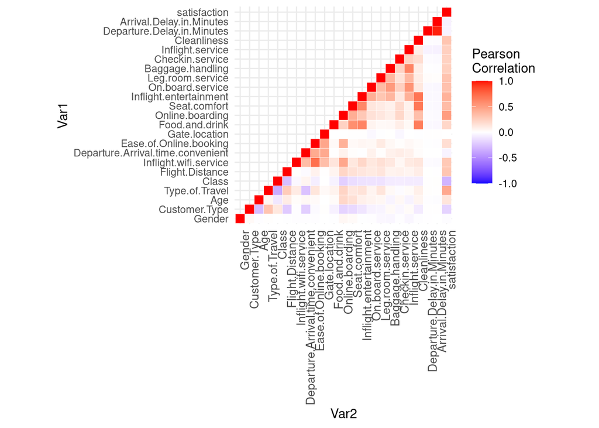

```r
library(reshape2)
library(ggplot2)

cor_matrix <- cor(df_enc)
cor_matrix[lower.tri(cor_matrix)]<- NA
cor_matrix_melted <- melt(cor_matrix, na.rm = TRUE)


ggplot(data = cor_matrix_melted, aes(Var2, Var1, fill = value))+
 geom_tile(color = "white")+
 scale_fill_gradient2(low = "blue", high = "red", mid = "white",
   midpoint = 0, limit = c(-1,1), space = "Lab",
   name="Pearson\nCorrelation") +
  theme_minimal()+
 theme(axis.text.x = element_text(angle = 90, vjust = 1,
    size = 10, hjust = 1))+
 coord_fixed()
```

## Logistic GLM

Now the logit-model shall be built using the GLM syntax, with summary being called to display t-values, P-values estimated coefficients and the associated errors

### Explanation of Coefficients

[output not shown]

```r
logmodel <- glm(
  satisfaction ~ ., family = binomial, data =  df_enc
)
summary(logmodel)
```

```
##
## Call:
## glm(formula = satisfaction ~ ., family = binomial, data = df_enc)
##
## Deviance Residuals:
##     Min       1Q   Median       3Q      Max
## -2.8043  -0.5013  -0.1744   0.3919   3.9871
##
## Coefficients:
##                                     Estimate Std. Error z value Pr(>|z|)
## (Intercept)                       -1.004e+01  1.108e-01 -90.538  < 2e-16 ***
## Gender                            -5.315e-02  1.936e-02  -2.745  0.00604 **
## Customer.Type                     -2.048e+00  2.947e-02 -69.500  < 2e-16 ***
## Age                               -7.601e-03  7.065e-04 -10.759  < 2e-16 ***
## Type.of.Travel                     3.041e+00  2.952e-02 103.010  < 2e-16 ***
## Class                             -1.941e-01  1.692e-02 -11.471  < 2e-16 ***
## Flight.Distance                    8.388e-05  1.069e-05   7.849 4.20e-15 ***
## Inflight.wifi.service              3.490e-01  1.135e-02  30.753  < 2e-16 ***
## Departure.Arrival.time.convenient -1.251e-01  8.163e-03 -15.329  < 2e-16 ***
## Ease.of.Online.booking            -1.291e-01  1.134e-02 -11.386  < 2e-16 ***
## Gate.location                      2.851e-02  9.120e-03   3.126  0.00177 **
## Food.and.drink                    -2.158e-02  1.064e-02  -2.028  0.04255 *
## Online.boarding                    6.418e-01  1.016e-02  63.180  < 2e-16 ***
## Seat.comfort                       8.537e-02  1.109e-02   7.701 1.35e-14 ***
## Inflight.entertainment             3.371e-02  1.417e-02   2.379  0.01737 *
## On.board.service                   3.247e-01  1.010e-02  32.144  < 2e-16 ***
## Leg.room.service                   2.594e-01  8.480e-03  30.587  < 2e-16 ***
## Baggage.handling                   1.546e-01  1.140e-02  13.562  < 2e-16 ***
## Checkin.service                    3.391e-01  8.510e-03  39.853  < 2e-16 ***
## Inflight.service                   1.438e-01  1.200e-02  11.986  < 2e-16 ***
## Cleanliness                        2.217e-01  1.208e-02  18.359  < 2e-16 ***
## Departure.Delay.in.Minutes         4.917e-03  9.802e-04   5.016 5.27e-07 ***
## Arrival.Delay.in.Minutes          -9.669e-03  9.662e-04 -10.008  < 2e-16 ***
## ---
## Signif. codes:  0 '***' 0.001 '**' 0.01 '*' 0.05 '.' 0.1 ' ' 1
##
## (Dispersion parameter for binomial family taken to be 1)
##
##     Null deviance: 141768  on 103593  degrees of freedom
## Residual deviance:  69983  on 103571  degrees of freedom
## AIC: 70029
##
## Number of Fisher Scoring iterations: 6
```

### Confidence Intervals

The confidence intervals for the parameters at level 0.95 are found using the confint-function as shown below

```r
confint(logmodel, level = 0.95)
```

```
##                                           2.5 %        97.5 %
## (Intercept)                       -1.025376e+01 -9.8192386732
## Gender                            -9.108777e-02 -0.0152057683
## Customer.Type                     -2.105884e+00 -1.9903712089
## Age                               -8.986583e-03 -0.0062172297
## Type.of.Travel                     2.983640e+00  3.0993769312
## Class                             -2.271846e-01 -0.1608662053
## Flight.Distance                    6.293752e-05  0.0001048281
## Inflight.wifi.service              3.268094e-01  0.3712993688
## Departure.Arrival.time.convenient -1.411304e-01 -0.1091317961
## Ease.of.Online.booking            -1.513174e-01 -0.1068752139
## Gate.location                      1.063890e-02  0.0463908970
## Food.and.drink                    -4.245156e-02 -0.0007349746
## Online.boarding                    6.219316e-01  0.6617524289
## Seat.comfort                       6.364586e-02  0.1071004859
## Inflight.entertainment             5.924870e-03  0.0614700981
## On.board.service                   3.049551e-01  0.3445566583
## Leg.room.service                   2.427696e-01  0.2760117982
## Baggage.handling                   1.322284e-01  0.1769016572
## Checkin.service                    3.224714e-01  0.3558289800
## Inflight.service                   1.203145e-01  0.1673501398
## Cleanliness                        1.980762e-01  0.2454208329
## Departure.Delay.in.Minutes         2.998317e-03  0.0068407839
## Arrival.Delay.in.Minutes          -1.156619e-02 -0.0077788492
```